# act_report

## Wrangle and Analyze Data Project: Analysis Report

#### By: Isra Bazzar

### Documentation of analysis and insights into final data

First of all, let me tell you a little about our data and what's it about:

#### Data Summary

The data is tweet archive of Twitter user @dog_rates, also known as WeRateDogs. WeRateDogs is a Twitter account that rates people's dogs with a humorous comment about the dog. These ratings almost always have a denominator of 10. The numerators, though? Almost always greater than 10. 11/10, 12/10, 13/10, etc. Why? Because "they're good dogs Brent." WeRateDogs has over 4 million followers and has received international media coverage.

This analysis have focused on how dog type affects other variables:

#### Dog count vs. Dog Type

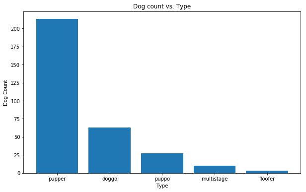

```python
from IPython.display import Image
Image("img/plot1.png")
```

#### Check above plot represents dog count vs. dog type: note the most common type is pupper, while the most rare type is floofer

#### Dog avg rating vs. Dog Type

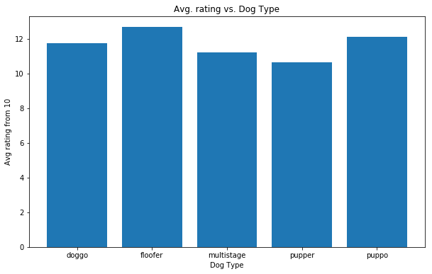

```python
from IPython.display import Image
Image("img/plot2.png")
```

#### Check above plot represents dog count vs. avg. rating for all dogs in each type : note the highest rated type is the most rare one! (floofer), while the least avg rating acheived by most common type(pupper), Interesting!

### Further more analysis I found some interesting Insights:

1. Most common dog type is pupper then doggo then puppo then the least common is floofer type
2. Highest rated type is floofer vs. the lowest rated is pupper
3. Mostly retweets are for floofer
4. Mostly favorites for floofer also

   > Noted that Floofer type is the most liked but most rare
5. Mean retweet_count is 2785 and mean favorite_count is 8971